# Module1

### Grading

The final score that you will receive for your programming assignment is generated in relation to the total points set in your programming assignment item—not the total point value in the nbgrader notebook.  
When calculating the final score shown to learners, the programming assignment takes the percentage of earned points vs. the total points provided by nbgrader and returns a score matching the equivalent percentage of the point value for the programming assignment.  
**DO NOT CHANGE VARIABLE OR METHOD SIGNATURES** The autograder will not work properly if your change the variable or method signatures.

### Validate Button

Please note that this assignment uses nbgrader to facilitate grading. You will see a **validate button** at the top of your Jupyter notebook. If you hit this button, it will run tests cases for the lab that aren't hidden. It is good to use the validate button before submitting the lab. Do know that the labs in the course contain hidden test cases. The validate button will not let you know whether these test cases pass. After submitting your lab, you can see more information about these hidden test cases in the Grader Output.  
*Cells with longer execution times will cause the validate button to time out and freeze. Please know that if you run into Validate time-outs, it will not affect the final submission grading.*

# Part 1. Data cleaning and Exploratory Data Analysis (EDA)

This part will practice data cleaning and Exploratory Data Analysis (EDA) using a house price dataset and mpg dataset.  
The first dataset is from a Kaggle competition (https://www.kaggle.com/c/house-prices-advanced-regression-techniques/overview), where the task is to predict a house sale price given house features.

```python
!ls
```

```
data  Module1.ipynb
```

```python
import pandas as pd
import matplotlib.pyplot as plt
import numpy as np
import math
```

## 1. Import data and visually inspect the table [9 pts]

### 1a) Data import and basic inspection. [5 pts]

We can import the csv data using `pd.read_csv()` function. We can use `df.head()` and `df.tail()` to show the first and last 5 entries. `df.iloc[[3,5,7]]` shows the entries corresponding to the index 3,5,7. What is the maximum value of the feature `MSSubClass` among the last 10 entries? Update the value of `maxval` to the correct integer value.

```python
df = pd.read_csv('data/house_data.csv') #it is the same data as the kaggle competition's train.csv.
# your code here
#df.head()
max(df.tail(10)["MSSubClass"])
df.tail(10)
# uncomment maxval and update the correct integer value
maxval = 180
```

```python
# this cell tests that you correctly updated maxval
```

### 1b) df.info() gives the overview of the data frame. Inspect the data using df.info() and answer below questions. [4 pts]

#### 1b-i) Which column is the target?

#### 1b-ii) How many features are in the data? Exclude the target. (Id is not a useful feature, but let's still include)

#### 1b-iii) How many observations (samples) are in the data?

#### 1b-iv) How many features have null values based on the data overview?

```python
# your code here
df.info()

# uncomment and update to the correct string value
# copy directly from the uneditd df column name (e.g., 'LandContour')
ANS_1b1 = 'SalePrice'
# uncomment and update to the correct integer value
ANS_1b2 = 80
# uncomment and update to the correct integer value
ANS_1b3 = 1460
# uncomment and update to the correct integer value
ANS_1b4 = 19
```

```
<class 'pandas.core.frame.DataFrame'>
RangeIndex: 1460 entries, 0 to 1459
Data columns (total 81 columns):
 #   Column         Non-Null Count  Dtype
---  ------         --------------  -----
 0   Id             1460 non-null   int64
 1   MSSubClass     1460 non-null   int64
 2   MSZoning       1460 non-null   object
 3   LotFrontage    1201 non-null   float64
 4   LotArea        1460 non-null   int64
 5   Street         1460 non-null   object
 6   Alley          91 non-null     object
 7   LotShape       1460 non-null   object
 8   LandContour    1460 non-null   object
 9   Utilities      1460 non-null   object
```

[output cut: 73 more lines]

```python
# this cell will test your solutions to the four questions above
```

## 2. Inspect Null values [16 pts]

The empty values in the data are called null values. Null values can take different forms. Have a look at below example. `np.nan` and `None` are native null values in python. They get displayed differently in the pandas dataframe (`pd.DataFrame`) though. But there are other data types such as empty list, empty dictionary, etc and string values that literally says "null" or that are empty spaces. Depending on how messy the data is, sometimes the table may have null values of one or more kinds, and those can be cleaned manually or automatically if you can write a code to include all possible cases which meanings are null values.

```python
a = [np.nan, None, [], {}, 'NaN', 'Null','NULL','None','NA','?','-', '.','', ' ', '   ']
nulldemo = pd.DataFrame(a)
nulldemo
```

|  | 0 |
| --- | --- |
| 0 | NaN |
| 1 | None |
| 2 | [] |
| 3 | {} |
| 4 | NaN |
| 5 | Null |
| 6 | NULL |
| 7 | None |
| 8 | NA |
| 9 | ? |
| 10 | - |
| 11 | . |
| 12 |  |
| 13 |  |
| 14 |  |

`.isnull()` method applied to pandas dataframe or series can detect null values. `.dropna()` method in pandas will detect null values and can be specified to drop either rows or columns that contain null values. Below shows that `.isnull()` only detects the python-native null values and cannot detect other forms (string value) of variables that meant null.

```python
nulldemo.isnull()
```

|  | 0 |
| --- | --- |
| 0 | True |
| 1 | True |
| 2 | False |
| 3 | False |
| 4 | False |
| 5 | False |
| 6 | False |
| 7 | False |
| 8 | False |
| 9 | False |
| 10 | False |
| 11 | False |
| 12 | False |
| 13 | False |
| 14 | False |

Also, sometimes the python-native null values can have an odd data type such as numpy float.

```python
print(df['MasVnrArea'].iloc[234], df['MasVnrArea'].iloc[234].dtype, type(df['MasVnrArea'].iloc[234]))
print(df['MasVnrArea'].isnull().iloc[234])
print(np.isnan(df['MasVnrArea'].iloc[234]))
print(math.isnan(df['MasVnrArea'].iloc[234]))
print(df['MasVnrArea'].iloc[234]==np.nan)
print(df['MasVnrArea'].iloc[234]==np.float64(np.nan))
```

```
nan float64 <class 'numpy.float64'>
True
True
True
False
False
```

np.isnan() and math.isnan() can detect the nan values with numpy float type, but they will cause errors with native `None` or a string value. Uncomment one of below (one at a time) and run. You'll see error messages.

```python
# your code here


#print(np.isnan(None))
#print(np.isnan('None'))
#print(math.isnan(None))
#print(math.isnan('None'))
```

### 2a) Check null values type [5 pts]

Let's check if our data has clean null values (one kind) or messy null values (multiple different representations). Run the codes below and visually inspect the printed results. Which column has string-typed null/none values and how many elements are string-typed null/none values?

```python
# prints number of null values detected by .isnull() and string none
for c in df.columns:
    string_null = np.array([x in a[2:] for x in df[c]])
    print(c, df[c].isnull().sum(), string_null.sum())
```

```
Id 0 0
MSSubClass 0 0
MSZoning 0 0
LotFrontage 259 0
LotArea 0 0
Street 0 0
Alley 1369 0
LotShape 0 0
LandContour 0 0
Utilities 0 0
LotConfig 0 0
LandSlope 0 0
Neighborhood 0 0
Condition1 0 0
Condition2 0 0
BldgType 0 0
HouseStyle 0 0
OverallQual 0 0
OverallCond 0 0
YearBuilt 0 0
YearRemodAdd 0 0
RoofStyle 0 0
RoofMatl 0 0
Exterior1st 0 0
Exterior2nd 0 0
MasVnrType 8 864
MasVnrArea 8 0
ExterQual 0 0
ExterCond 0 0
Foundation 0 0
BsmtQual 37 0
BsmtCond 37 0
BsmtExposure 38 0
BsmtFinType1 37 0
BsmtFinSF1 0 0
BsmtFinType2 38 0
BsmtFinSF2 0 0
BsmtUnfSF 0 0
TotalBsmtSF 0 0
Heating 0 0
```

[output cut: 26 more lines]

```
WoodDeckSF 0 0
OpenPorchSF 0 0
EnclosedPorch 0 0
3SsnPorch 0 0
ScreenPorch 0 0
PoolArea 0 0
PoolQC 1453 0
Fence 1179 0
MiscFeature 1406 0
MiscVal 0 0
MoSold 0 0
YrSold 0 0
SaleType 0 0
SaleCondition 0 0
SalePrice 0 0
```

Which column has string-typed null/none values?

```python
# your code here
#c.isnull()
# uncomment and update to the correct string value
col = 'MasVnrType'
```

How many elements are string-typed null/none values?

```python
# your code here

# uncomment and update to the correct string value
string_null_count = 864
```

```python
# this cell will test your answer about the column with string-typed null/none values
# and the number of string-typed null/none values
```

### 2b) Inspect observations (rows) with null values. How many observations have at least one missing value? [5 pts]

```python
# your code here

# uncomment and update to the correct integer value
rows_with_nulls = 1460
```

```python
# this cell will test your answer about the number of rows with null values
```

### 2c) Make a histogram of null counts [6 pts]

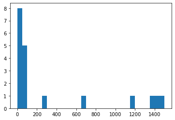

```python
# your code here
#print(df.isna().sum())
nulls = df.isnull().sum()
# Please uncomment and update
# do not change the names of the variables from null_counts and histogram
null_counts = pd.Series(df.isnull().sum()[df.isnull().sum() > 0])
histogram = plt.hist(null_counts, bins = np.arange(0, 1550, 50)) # replace the histogram to be the plt.hist() object.

# Hint: Use .isnull() and sum over True values on columns.
# You can make it as short as 2-3 lines of code
```

```python
# hidden test 1; tests null_counts
```

```python
# hidden test 2; tests histogram
```

## 3. Imputing missing values [33 pts]

In this part, we will decide methods to clean the data with missing values.

Complete case analysis (CCA) is to drop any observations (rows) that have null values. It is suitable if the number of observations with null values are very small (say, less than 5%) compared to the total number of observations.

If the data has a large number of features (columns) and the model(s) does not need that many features (some models work better with less number of features), we can consider dropping features that have many missing values. Before dropping features, it is generally a good idea checking whether the feature with missing values is important feature or not (which may need the analyst's judgement). If the feature is very important for the prediction task (for example, a house size when predicting house price) but has a large amount of missing values, we cannot simply drop the feature, or in a rare case, it could mean that the data is not suitable for the analysis. One will have to work with only the observations that has values on that feature given the number of observations is sufficient, or collect more data. If we know that those features are not very important and have a large number of missing values, we can drop the features. As a rule of thumb, features with missing values more than either 5% or 10% can be dropped.

### 3a) Is the data suitable for complete case analysis or not? [5 pts]

```python
# your code here


# uncomment and update to string 'no' or 'yes'
suitable_cca = 'no'
```

```python
# tests solution for whether data is suitable for CCA
```

### 3b) Dropping feature columns [20 pts]

Let's assume we want to keep columns that have null values 5% or less and discard any column that has null values more than 5%. Treat the string type "None" as a category and not null value.

#### 3b-i) According to above condition, how many features can be kept and imputed? [5 pts]

#### 3b-ii) Which columns have null values 5% or less of total, so we can impute? [5 pts]

#### 3b-iii) Which columns have null vaues more than 5% of total, so we should throw? [5 pts]

```python
# your code here
nonzero = pd.Series(((df.isnull().sum()/1460)*100)[(df.isnull().sum()/1460*100) > 0])
impute = pd.Series(nonzero[nonzero <= 5])
throw = pd.Series(nonzero[nonzero > 5])


print(impute)
print(throw)

# Complete the codes below by uncommenting and changing the values of features_to_impute and features_to_throw.
# Each should be a list of feature names (e.g. ['LotFrontage','Alley',...]). Do not change the variable names.
# There are hidden tests which will grade above three questions.

features_to_impute = impute.index.tolist()
features_to_throw = throw.index.tolist()
print(len(features_to_impute), features_to_impute)
print(len(features_to_throw), features_to_throw)
```

```
MasVnrType      0.547945
MasVnrArea      0.547945
BsmtQual        2.534247
BsmtCond        2.534247
BsmtExposure    2.602740
BsmtFinType1    2.534247
BsmtFinType2    2.602740
Electrical      0.068493
dtype: float64
LotFrontage     17.739726
Alley           93.767123
FireplaceQu     47.260274
GarageType       5.547945
GarageYrBlt      5.547945
GarageFinish     5.547945
GarageQual       5.547945
GarageCond       5.547945
PoolQC          99.520548
Fence           80.753425
MiscFeature     96.301370
dtype: float64
8 ['MasVnrType', 'MasVnrArea', 'BsmtQual', 'BsmtCond', 'BsmtExposure', 'BsmtFinType1', 'BsmtFinType2', 'Electrical']
11 ['LotFrontage', 'Alley', 'FireplaceQu', 'GarageType', 'GarageYrBlt', 'GarageFinish', 'GarageQual', 'GarageCond', 'PoolQC', 'Fence', 'MiscFeature']
```

```python
# Hidden test for 3b-i
```

```python
# Hidden test for 3b-ii
```

```python
# Hidden test for 3b-iii
```

### 3b-iv) Remove the columns according to the above result. Replace the `df` with the new result. Also remove `Id` column as it's not a useful feature. [5 pts]

```python
# your code here
df = df.drop(features_to_throw, axis = 1)
df = df.drop(['Id'], axis = 1)
# remove the columns according to the above result, replace df with the new results
# also remove ID column as it's not a useful feature
df
```

|  | MSSubClass | MSZoning | LotArea | Street | LotShape | LandContour | Utilities | LotConfig | LandSlope | Neighborhood | ... | EnclosedPorch | 3SsnPorch | ScreenPorch | PoolArea | MiscVal | MoSold | YrSold | SaleType | SaleCondition | SalePrice |
| --- | --- | --- | --- | --- | --- | --- | --- | --- | --- | --- | --- | --- | --- | --- | --- | --- | --- | --- | --- | --- | --- |
| 0 | 60 | RL | 8450 | Pave | Reg | Lvl | AllPub | Inside | Gtl | CollgCr | ... | 0 | 0 | 0 | 0 | 0 | 2 | 2008 | WD | Normal | 208500 |
| 1 | 20 | RL | 9600 | Pave | Reg | Lvl | AllPub | FR2 | Gtl | Veenker | ... | 0 | 0 | 0 | 0 | 0 | 5 | 2007 | WD | Normal | 181500 |
| 2 | 60 | RL | 11250 | Pave | IR1 | Lvl | AllPub | Inside | Gtl | CollgCr | ... | 0 | 0 | 0 | 0 | 0 | 9 | 2008 | WD | Normal | 223500 |
| 3 | 70 | RL | 9550 | Pave | IR1 | Lvl | AllPub | Corner | Gtl | Crawfor | ... | 272 | 0 | 0 | 0 | 0 | 2 | 2006 | WD | Abnorml | 140000 |
| 4 | 60 | RL | 14260 | Pave | IR1 | Lvl | AllPub | FR2 | Gtl | NoRidge | ... | 0 | 0 | 0 | 0 | 0 | 12 | 2008 | WD | Normal | 250000 |
| ... | ... | ... | ... | ... | ... | ... | ... | ... | ... | ... | ... | ... | ... | ... | ... | ... | ... | ... | ... | ... | ... |
| 1455 | 60 | RL | 7917 | Pave | Reg | Lvl | AllPub | Inside | Gtl | Gilbert | ... | 0 | 0 | 0 | 0 | 0 | 8 | 2007 | WD | Normal | 175000 |
| 1456 | 20 | RL | 13175 | Pave | Reg | Lvl | AllPub | Inside | Gtl | NWAmes | ... | 0 | 0 | 0 | 0 | 0 | 2 | 2010 | WD | Normal | 210000 |
| 1457 | 70 | RL | 9042 | Pave | Reg | Lvl | AllPub | Inside | Gtl | Crawfor | ... | 0 | 0 | 0 | 0 | 2500 | 5 | 2010 | WD | Normal | 266500 |
| 1458 | 20 | RL | 9717 | Pave | Reg | Lvl | AllPub | Inside | Gtl | NAmes | ... | 112 | 0 | 0 | 0 | 0 | 4 | 2010 | WD | Normal | 142125 |
| 1459 | 20 | RL | 9937 | Pave | Reg | Lvl | AllPub | Inside | Gtl | Edwards | ... | 0 | 0 | 0 | 0 | 0 | 6 | 2008 | WD | Normal | 147500 |

1460 rows × 69 columns

```python
# tests that you properly updated df
```

### 3c) Impute missing data [8 pts]

Before imputing columns, we need to think about what methods to use to impute columns. The imputation strategy can be different depending on the variable types and variable value distribution. There are many imputation techniques, but let's use a few simple ones.

For a numerical variable imputation, we impute mean value if the distribution is symmetric while we use median value to impute when the distribution is skewed. Another method is to assign an arbitrary value that's outside the normal range. Though it can be useful to capture missingness, but it can create outliers. Both mean/median and arbitrary imputation methods are simple to use and suitable when missing values are 5% (no more than 10%) as a rule of thumb. Both methods can distort the original distribution.

For a categorical variable imputation, we can impute with the most frequent categorical value. It is a simple method but it can distort the original distribution. It is also possible to create a "missing" category to capture missingness. The advantage of using missing category is that it captures missingness but its disadvantage is that it creates another rare category.

Below code shows histograms of feature columns that we can impute.

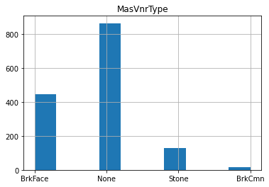

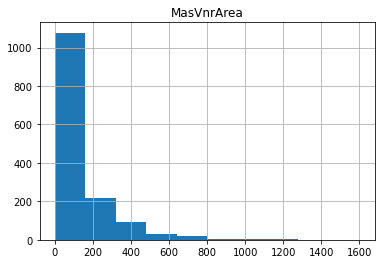

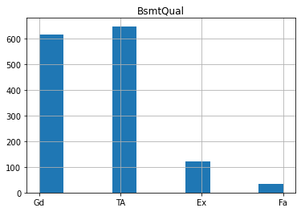

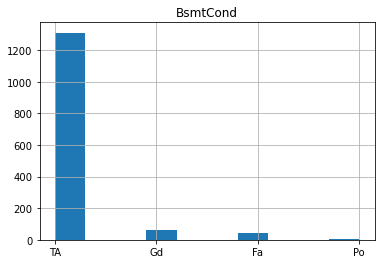

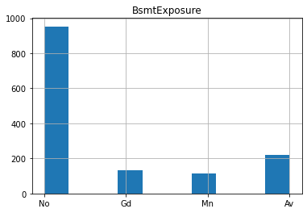

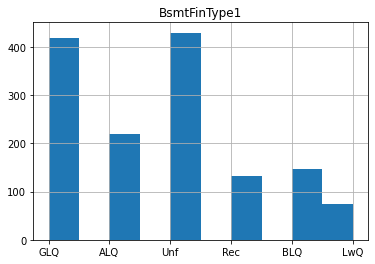

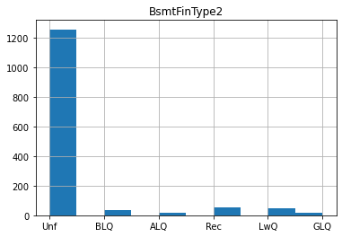

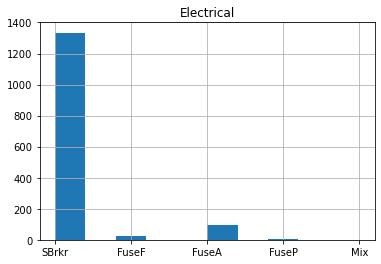

```python
for c in features_to_impute:
    df[c].hist()
    plt.title(c)
    plt.show()
```

### 3c-i) Impute missing data for features in `features_to_impute`. Choose an appropriate method among mean or median imputation methods for numerical variable(s) and frequentest value imputation for categorical variable(s). [8 pts]

You can inspect variable types by eyes, or use below code as a help. Replace those columns with imputed values. Do not change the column name or the data frame name. Do not add new columns to the data frame.  
Hint: You can use .mode() function to find the most frequent value in a Series.  
Hint: You may use .fillna() function on each feature Series.

```python
for c in features_to_impute:
    print(c, len(df[c].unique()), df[c].dtype)
```

```
MasVnrType 5 object
MasVnrArea 328 float64
BsmtQual 5 object
BsmtCond 5 object
BsmtExposure 5 object
BsmtFinType1 7 object
BsmtFinType2 7 object
Electrical 6 object
```

```python
# your code here
#df['MasVnrType'] = df['MasVnrType'].fillna(value = 'BrkFace')
#df['MasVnrType']

#for c in features_to_impute:
#    df[c].hist()
#    plt.title(c)
#    plt.show()
#for c in features_to_impute:
#    print(c, (df[c].unique()), df[c].dtype)
# use this cell for potential debugging
```

```python
# impute missing data
# your code here
#print(temp)
df['MasVnrArea'] = df['MasVnrArea'].fillna(df['MasVnrArea'].median())
df['MasVnrType'] = df['MasVnrType'].fillna(df['MasVnrType'].value_counts().index[0])
df['BsmtQual'] = df['BsmtQual'].fillna(df['BsmtQual'].value_counts().index[0])
df['BsmtCond'] = df['BsmtCond'].fillna(df['BsmtCond'].value_counts().index[0])
df['BsmtExposure'] = df['BsmtExposure'].fillna(df['BsmtExposure'].value_counts().index[0])
df['BsmtFinType1'] = df['BsmtFinType1'].fillna(df['BsmtFinType1'].value_counts().index[0])
df['BsmtFinType2'] = df['BsmtFinType2'].fillna(df['BsmtFinType2'].value_counts().index[0])
df['Electrical'] = df['Electrical'].fillna(df['Electrical'].value_counts().index[0])



#for c in features_to_impute:
#    df[c].hist()
#    plt.title(c)
#    plt.show()

for c in features_to_impute:
    print(c, (df[c].unique()), df[c].dtype)
```

```
MasVnrType ['BrkFace' 'None' 'Stone' 'BrkCmn'] object
MasVnrArea [1.960e+02 0.000e+00 1.620e+02 3.500e+02 1.860e+02 2.400e+02 2.860e+02
 3.060e+02 2.120e+02 1.800e+02 3.800e+02 2.810e+02 6.400e+02 2.000e+02
 2.460e+02 1.320e+02 6.500e+02 1.010e+02 4.120e+02 2.720e+02 4.560e+02
 1.031e+03 1.780e+02 5.730e+02 3.440e+02 2.870e+02 1.670e+02 1.115e+03
 4.000e+01 1.040e+02 5.760e+02 4.430e+02 4.680e+02 6.600e+01 2.200e+01
 2.840e+02 7.600e+01 2.030e+02 6.800e+01 1.830e+02 4.800e+01 2.800e+01
 3.360e+02 6.000e+02 7.680e+02 4.800e+02 2.200e+02 1.840e+02 1.129e+03
 1.160e+02 1.350e+02 2.660e+02 8.500e+01 3.090e+02 1.360e+02 2.880e+02
 7.000e+01 3.200e+02 5.000e+01 1.200e+02 4.360e+02 2.520e+02 8.400e+01
 6.640e+02 2.260e+02 3.000e+02 6.530e+02 1.120e+02 4.910e+02 2.680e+02
 7.480e+02 9.800e+01 2.750e+02 1.380e+02 2.050e+02 2.620e+02 1.280e+02
 2.600e+02 1.530e+02 6.400e+01 3.120e+02 1.600e+01 9.220e+02 1.420e+02
 2.900e+02 1.270e+02 5.060e+02 2.970e+02 6.040e+02 2.540e+02 3.600e+01
 1.020e+02 4.720e+02 4.810e+02 1.080e+02 3.020e+02 1.720e+02 3.990e+02
 2.700e+02 4.600e+01 2.100e+02 1.740e+02 3.480e+02 3.150e+02 2.990e+02
 3.400e+02 1.660e+02 7.200e+01 3.100e+01 3.400e+01 2.380e+02 1.600e+03
 3.650e+02 5.600e+01 1.500e+02 2.780e+02 2.560e+02 2.250e+02 3.700e+02
 3.880e+02 1.750e+02 2.960e+02 1.460e+02 1.130e+02 1.760e+02 6.160e+02
 3.000e+01 1.060e+02 8.700e+02 3.620e+02 5.300e+02 5.000e+02 5.100e+02
 2.470e+02 3.050e+02 2.550e+02 1.250e+02 1.000e+02 4.320e+02 1.260e+02
 4.730e+02 7.400e+01 1.450e+02 2.320e+02 3.760e+02 4.200e+01 1.610e+02
 1.100e+02 1.800e+01 2.240e+02 2.480e+02 8.000e+01 3.040e+02 2.150e+02
 7.720e+02 4.350e+02 3.780e+02 5.620e+02 1.680e+02 8.900e+01 2.850e+02
 3.600e+02 9.400e+01 3.330e+02 9.210e+02 7.620e+02 5.940e+02 2.190e+02
 1.880e+02 4.790e+02 5.840e+02 1.820e+02 2.500e+02 2.920e+02 2.450e+02
 2.070e+02 8.200e+01 9.700e+01 3.350e+02 2.080e+02 4.200e+02 1.700e+02
 4.590e+02 2.800e+02 9.900e+01 1.920e+02 2.040e+02 2.330e+02 1.560e+02
 4.520e+02 5.130e+02 2.610e+02 1.640e+02 2.590e+02 2.090e+02 2.630e+02
 2.160e+02 3.510e+02 6.600e+02 3.810e+02 5.400e+01 5.280e+02 2.580e+02
 4.640e+02 5.700e+01 1.470e+02 1.170e+03 2.930e+02 6.300e+02 4.660e+02
 1.090e+02 4.100e+01 1.600e+02 2.890e+02 6.510e+02 1.690e+02 9.500e+01
 4.420e+02 2.020e+02 3.380e+02 8.940e+02 3.280e+02 6.730e+02 6.030e+02
 1.000e+00 3.750e+02 9.000e+01 3.800e+01 1.570e+02 1.100e+01 1.400e+02
 1.300e+02 1.480e+02 8.600e+02 4.240e+02 1.047e+03 2.430e+02 8.160e+02
 3.870e+02 2.230e+02 1.580e+02 1.370e+02 1.150e+02 1.890e+02 2.740e+02
 1.170e+02 6.000e+01 1.220e+02 9.200e+01 4.150e+02 7.600e+02 2.700e+01
 7.500e+01 3.610e+02 1.050e+02 3.420e+02 2.980e+02 5.410e+02 2.360e+02
 1.440e+02 4.230e+02 4.400e+01 1.510e+02 9.750e+02 4.500e+02 2.300e+02
 5.710e+02 2.400e+01 5.300e+01 2.060e+02 1.400e+01 3.240e+02 2.950e+02
 3.960e+02 6.700e+01 1.540e+02 4.250e+02 4.500e+01 1.378e+03 3.370e+02
 1.490e+02 1.430e+02 5.100e+01 1.710e+02 2.340e+02 6.300e+01 7.660e+02
 3.200e+01 8.100e+01 1.630e+02 5.540e+02 2.180e+02 6.320e+02 1.140e+02
 5.670e+02 3.590e+02 4.510e+02 6.210e+02 7.880e+02 8.600e+01 7.960e+02
 3.910e+02 2.280e+02 8.800e+01 1.650e+02 4.280e+02 4.100e+02 5.640e+02
 3.680e+02 3.180e+02 5.790e+02 6.500e+01 7.050e+02 4.080e+02 2.440e+02
 1.230e+02 3.660e+02 7.310e+02 4.480e+02 2.940e+02 3.100e+02 2.370e+02
 4.260e+02 9.600e+01 4.380e+02 1.940e+02 1.190e+02] float64
BsmtQual ['Gd' 'TA' 'Ex' 'Fa'] object
BsmtCond ['TA' 'Gd' 'Fa' 'Po'] object
BsmtExposure ['No' 'Gd' 'Mn' 'Av'] object
BsmtFinType1 ['GLQ' 'ALQ' 'Unf' 'Rec' 'BLQ' 'LwQ'] object
BsmtFinType2 ['Unf' 'BLQ' 'ALQ' 'Rec' 'LwQ' 'GLQ'] object
Electrical ['SBrkr' 'FuseF' 'FuseA' 'FuseP' 'Mix'] object
```

```python
# tests 'MasVnrType' and 'MasVnrArea'
```

```python
# tsts 'BsmtQual' and 'BsmtCond'
```

```python
# tests 'BsmtExposure' and 'BsmtFinType1'
```

```python
# tests 'BsmtFinType2' and 'Electrical'
```

# Part 2. EDA, Simple Linear Regression

In this part, we will use a simplified data and create a simple linear regression model. The dataset can be downloaded from https://www.kaggle.com/harlfoxem/housesalesprediction/download.  
This dataset contains house sale prices for Kings County, which includes Seattle. It includes homes sold between May 2014 and May 2015. There are several versions of the data. Some additional information about the columns is available here: https://geodacenter.github.io/data-and-lab/KingCounty-HouseSales2015/, some of which are copied below.

| Variable | Description |
| --- | --- |
| id | Identification |
| date | Date sold |
| price | Sale price |
| bedrooms | Number of bedrooms |
| bathrooms | Number of bathrooms |
| sqft_liv | Size of living area in square feet |
| sqft_lot | Size of the lot in square feet |
| floors | Number of floors |
| waterfront | ‘1’ if the property has a waterfront, ‘0’ if not. |
| view | An index from 0 to 4 of how good the view of the property was |
| condition | Condition of the house, ranked from 1 to 5 |
| grade | Classification by construction quality which refers to the types of materials used and the quality of workmanship. Buildings of better quality (higher grade) cost more to build per unit of measure and… |
| sqft_above | Square feet above ground |
| sqft_basmt | Square feet below ground |
| yr_built | Year built |
| yr_renov | Year renovated. ‘0’ if never renovated |
| zipcode | 5 digit zip code |
| lat | Latitude |
| long | Longitude |
| squft_liv15 | Average size of interior housing living space for the closest 15 houses, in square feet |
| squft_lot15 | Average size of land lost for the closest 15 houses, in square feet |

```python
import scipy as sp
import scipy.stats as stats
import pandas as pd
import numpy as np
import matplotlib.pyplot as plt
import seaborn as sns
import copy
# Set color map to have light blue background
sns.set()
import statsmodels.formula.api as smf
import statsmodels.api as sm
%matplotlib inline
```

```python
df2 = pd.read_csv('data/house_data_washington.csv')
```

## 4. Munging data [15 pts]

### 4a) Date string to numbers [5 pts]

Inspect the data frame and data type of each column. The column 'date' is the date sold, and has string value. We will extract year and month information from the string. In the data frame df2, create new features 'sales_year' and 'sales_month'.

```python
# extract year and month info from the string
# create new features 'sales_year' and 'sales_month' in df2
df2['sales_year'] = df2.date.apply(lambda x: int(x[:4]))
df2['sales_month'] = df2.date.apply(lambda x: int(x[4:6]))
print(df2.groupby('sales_month')['id'].count())
print(df2.groupby('sales_year')['id'].count())
```

```
sales_month
1      978
2     1250
3     1875
4     2231
5     2414
6     2180
7     2211
8     1940
9     1774
10    1878
11    1411
12    1471
Name: id, dtype: int64
sales_year
2014    14633
2015     6980
Name: id, dtype: int64
```

Which month has the most number of sales?

```python
# your code here

# uncomment and update string with capitalized month, e.g., 'December'
most_sales = 'May'
```

Which months has the least number of sales?

```python
# your code here

# uncomment and update string with capitalized month, e.g., 'December'
least_sales = 'January'
```

```python
# tests solutions for most_sales and least_sales
```

```python
df2.info()
```

```
<class 'pandas.core.frame.DataFrame'>
RangeIndex: 21613 entries, 0 to 21612
Data columns (total 23 columns):
 #   Column         Non-Null Count  Dtype
---  ------         --------------  -----
 0   id             21613 non-null  int64
 1   date           21613 non-null  object
 2   price          21613 non-null  int64
 3   bedrooms       21613 non-null  int64
 4   bathrooms      21613 non-null  float64
 5   sqft_living    21613 non-null  int64
 6   sqft_lot       21613 non-null  int64
 7   floors         21613 non-null  float64
 8   waterfront     21613 non-null  int64
 9   view           21613 non-null  int64
 10  condition      21613 non-null  int64
 11  grade          21613 non-null  int64
 12  sqft_above     21613 non-null  int64
 13  sqft_basement  21613 non-null  int64
 14  yr_built       21613 non-null  int64
 15  yr_renovated   21613 non-null  int64
 16  zipcode        21613 non-null  int64
 17  lat            21613 non-null  float64
 18  long           21613 non-null  float64
 19  sqft_living15  21613 non-null  int64
 20  sqft_lot15     21613 non-null  int64
 21  sales_year     21613 non-null  int64
 22  sales_month    21613 non-null  int64
dtypes: float64(4), int64(18), object(1)
memory usage: 3.8+ MB
```

### 4b) Variable types [5 pts]

Inspect each feature's data type and variable type. What is the best description for the variable type of following features? Update the string to 'numeric' or 'categorical'.

```python
# your code here


# uncomment the feaures below and update the strings with 'numeric' or 'categorical'
price = 'numeric'
bathrooms = 'numeric'
waterfront = 'categorical'
grade = 'numeric'
zipcode = 'categorical'
sales_year = 'numeric'
```

```python
# tests that you selected correct variable type for the features in 4b
```

```python
# this part is ungraded, but useful to run to check
# your code here

for c in df2.columns[2:]:
    print(c, df2[c].unique())
```

```
bathrooms [1.   2.25 3.   2.   4.5  1.5  2.5  1.75 2.75 3.25 4.   3.5  0.75 4.75
 5.   4.25 3.75 0.   1.25 5.25 6.   0.5  5.5  6.75 5.75 8.   7.5  7.75
 6.25 6.5 ]
sqft_living [1180 2570  770 ... 3087 3118 1425]
sqft_lot [ 5650  7242 10000 ...  5813  2388  1076]
floors [1.  2.  1.5 3.  2.5 3.5]
waterfront [0 1]
view [0 3 4 2 1]
condition [3 5 4 1 2]
grade [ 7  6  8 11  9  5 10 12  4  3 13  1]
sqft_above [1180 2170  770 1050 1680 3890 1715 1060 1890 1860  860 1430 1370 1810
 1980 1600 1200 1250 2330 2270 1070 2450 1710 1750 1400  790 2570 2320
 1190 1510 1090 1280  930 2360  890 2620 2600 3595 1570  920 3160  990
 2290 2165 1640 1000 2130 2830 2250 2420 3250 1850 1590 1260 2519 1540
 1110 1770 2720 2240 3070 2380 2390  880 1040  910 3450 2350 1900 1010
  960 2660 1610  765 3520 1290 1960 1160 1210 1270 1440 2190 2920 1460
 1170 1240 3140 2030 2310  700 1080 2520 2780 1560 1450 1720 2910 1620
 1360 2070 2460 1390 2140 1320 1340 1550  940 1380 3670 2370 1130  980
 3540 2500 1760 1030 1780 3400 2680 1670 2590  820 1220 2440 2090 1100
 1330 1420 1690 2150 1910 1350 1940  900 1630 2714  850 1870 1950 2760
 2020 1120 1480 1230 2280 3760 3530  830 1300 2740 1830  720 2010 3360
  800 1730  760 1700 4750 5310  580 2653 2850 2210 2630 3500 1740 1140
 2160 2650  970 2040 2180 2220 1660 3370 2690 1930 3150 3030 2050 2490
 2560 1275 2580  560 1820 1840 2990 3230 1580 3480 2510 1410 2120 3300
 3840 1500 1530 2840  833 2000 6070  950 2200 4040 1920 1490 3470 3130
 2610 3260 2260  430 3390  630 4860 3860 2810  870 3180 2770 4030 4410
 2400 1520 3040 6050 4740 1970 5403 3350 3580 1790  750 2860 2750 2340
 2870 4120 3200 2550 1805 4150 1384 2060 2110 3590 2100 2540 1880 1150
 1470 1255 1800 4370 3190 2730 4570 2470  670 2900 4670 4230 2156 1020
 2940 2640 2710 3100 3610 4270  840 3090 2300  380 2480 3460 3060 3064
 3000 1654 2790 1310 2230 2430 3680 2670 2208  810  740 1422  490 2080
 3440 5670 4475  730 3410 3010  600 2960 3570 4300 3990  780 3020 5990
  440 4460 4190 2800 2530 1650 3690 2932 3720 4250 3110 2963 4930 2950
 5000 2452 2820 1981  640 2495 2403 5320 6720  660 2341 4210 3830 3280
 2980 5153 1990 1646  610  710 5450 3504 3210 1782 2930  590 4280  680
 3880 3430 3750 4130 5710 3380 3330 4700 3220 3362 3510 3810  620 4490
 2410 3050 1008 3488 4070 3420 5770 1605  520 1088 3555 4360 3960 2700
 4340 1552 3850 2303 3270 4350 3640 2174 4160 2496 5180 5130 6350 3770
 2153 3780 2890 1714 2201 2970  992 3950 3527 2835 3915 1427 4870 3340
 3620 4310 3930 4080 5400  570 3310 6110 3320 3490 3859 3710 1798 4600
```

[output cut: 213 more lines]

```
 1321 3045 1546 4730 2697 2822 2076 1757 4780  952 4270 2075 2667 1092
 1217 1716 1792 2961 1125 1463 1886  670 4460 2336 3557 5200 2258 1377
 2019 2092 4900 2615 1639 1765 1554 1381 4120 5080 1445 2793 2475  998
 2384 2575 1398 1584 2439 2197 2029 4362 1443 4420 1691 2495 2437 2547
 6210 2009 1847 1346 2578 2879 2255 2815 1608  690 2425 1481 2458 2358
 2056 1921 2419 2996 2502 1798 3087 1076 2981 2363 3191 1763 1876 1949
 2598 1979 1415 2002 2574 2166 3726 2099 2154 1522 1544 2912 2648 1658
 2755 2798 1405 2704 2738 3008 2586 2873 1232 2597 2516 1537 1128 2849
 1399 1131 1569 2381 1084 2304 4530 2297 2279 2303 2669 4225 2513 2725
 1955 2527 4443 2478 1919 1813 2533  828 2015 3078 4495 2673 2316 2647
 3402 3494 2156 3236 2612 2323 2409 2354 1285 2616 1427 1516 2456 2844
 1495 2594 2604 1268 2198 3038 2927]
sqft_lot15 [5650 7639 8062 ... 5731 1509 2007]
sales_year [2014 2015]
sales_month [10 12  2  5  6  1  4  3  7  8 11  9]
```

### 4c) Drop features [5 pts]

Let's drop features that are unnecessary. `id` is not a meaningful feature. `date` string has been coded to `sales_month` and `sales_year`, so we can remove `date`. `zipcode` can be also removed as it's hard to include in a linear regressio model and the location info is included in the `lat` and `long`. Drop the features `id`, `date`, and `zipcode` and replace the df2.

```python
# drop unnecessary features, replace df2
# your code here
df2 = df2.drop(['id', 'date', 'zipcode'], axis = 1)
```

[output not shown]

```python
# tests that you droppd the features id, date, and zipcode from df2
```

## 5. More inspection; Correlation and pair plot [5 pts and Peer Review]

### 5a) Get correlation matrix on the data frame. [5 pts]

Which feature may be the best predictor of price based on the correlation? Answer as a string value (e.g. best_guess_predictor = 'price' or best_guess_predictor = 'yr_built')

```python
# your code here
corrMatrix = df2.corr()
print(corrMatrix)
# uncomment and update best_guess_predictor with a string value
best_guess_predictor = 'sqft_living'
```

```
                  price  bedrooms  bathrooms  sqft_living  sqft_lot    floors  \
price          1.000000  0.308350   0.525138     0.702035  0.089661  0.256794
bedrooms       0.308350  1.000000   0.515884     0.576671  0.031703  0.175429
bathrooms      0.525138  0.515884   1.000000     0.754665  0.087740  0.500653
sqft_living    0.702035  0.576671   0.754665     1.000000  0.172826  0.353949
sqft_lot       0.089661  0.031703   0.087740     0.172826  1.000000 -0.005201
floors         0.256794  0.175429   0.500653     0.353949 -0.005201  1.000000
waterfront     0.266369 -0.006582   0.063744     0.103818  0.021604  0.023698
view           0.397293  0.079532   0.187737     0.284611  0.074710  0.029444
condition      0.036362  0.028472  -0.124982    -0.058753 -0.008958 -0.263768
grade          0.667434  0.356967   0.664983     0.762704  0.113621  0.458183
sqft_above     0.605567  0.477600   0.685342     0.876597  0.183512  0.523885
sqft_basement  0.323816  0.303093   0.283770     0.435043  0.015286 -0.245705
yr_built       0.054012  0.154178   0.506019     0.318049  0.053080  0.489319
yr_renovated   0.126434  0.018841   0.050739     0.055363  0.007644  0.006338
lat            0.307003 -0.008931   0.024573     0.052529 -0.085683  0.049614
long           0.021626  0.129473   0.223042     0.240223  0.229521  0.125419
sqft_living15  0.585379  0.391638   0.568634     0.756420  0.144608  0.279885
sqft_lot15     0.082447  0.029244   0.087175     0.183286  0.718557 -0.011269
sales_year     0.003576 -0.009838  -0.026596    -0.029038  0.005468 -0.022315
sales_month   -0.010081 -0.001533   0.007392     0.011810 -0.002369  0.014005

               waterfront      view  condition     grade  sqft_above  \
price            0.266369  0.397293   0.036362  0.667434    0.605567
bedrooms        -0.006582  0.079532   0.028472  0.356967    0.477600
bathrooms        0.063744  0.187737  -0.124982  0.664983    0.685342
sqft_living      0.103818  0.284611  -0.058753  0.762704    0.876597
sqft_lot         0.021604  0.074710  -0.008958  0.113621    0.183512
floors           0.023698  0.029444  -0.263768  0.458183    0.523885
waterfront       1.000000  0.401857   0.016653  0.082775    0.072075
view             0.401857  1.000000   0.045990  0.251321    0.167649
condition        0.016653  0.045990   1.000000 -0.144674   -0.158214
grade            0.082775  0.251321  -0.144674  1.000000    0.755923
sqft_above       0.072075  0.167649  -0.158214  0.755923    1.000000
sqft_basement    0.080588  0.276947   0.174105  0.168392   -0.051943
yr_built        -0.026161 -0.053440  -0.361417  0.446963    0.423898
yr_renovated     0.092885  0.103917  -0.060618  0.014414    0.023285
lat             -0.014274  0.006157  -0.014941  0.114084   -0.000816
long            -0.041910 -0.078400  -0.106500  0.198372    0.343803
sqft_living15    0.086463  0.280439  -0.092824  0.713202    0.731870
```

[output cut: 32 more lines]

```
floors              0.279885   -0.011269   -0.022315     0.014005
waterfront          0.086463    0.030703   -0.004165     0.008132
view                0.280439    0.072575    0.001364    -0.005638
condition          -0.092824   -0.003406   -0.045589     0.021978
grade               0.713202    0.119248   -0.030387     0.008376
sqft_above          0.731870    0.194050   -0.023823     0.009872
sqft_basement       0.200355    0.017276   -0.015687     0.006035
yr_built            0.326229    0.070958    0.003507    -0.006226
yr_renovated       -0.002673    0.007854   -0.023707     0.012827
lat                 0.048858   -0.086419   -0.029212     0.014961
long                0.334605    0.254451    0.000270    -0.008134
sqft_living15       1.000000    0.183192   -0.021734     0.002449
sqft_lot15          0.183192    1.000000   -0.000085     0.003546
sales_year         -0.021734   -0.000085    1.000000    -0.782389
sales_month         0.002449    0.003546   -0.782389     1.000000
```

```python
# tests the solution for best_guess_predictor
```

### 5b) Display the correlation matrix as heat map [Peer Review]

[`seaborn.heatmap()`](https://seaborn.pydata.org/generated/seaborn.heatmap.html) can visualize a matrix as a heatmap. Visualize the correlation matrix using seaborn.heatmap(). Play with color map, text font size, decimals, text orientation etc. If you find how to make a pretty visualization, please share in the discussion board. You will upload your correlation matrix in the Peer Review assigment for the week.  
**Note:** your code for this section may cause the Validate button to time out. If you want to run the Validate button prior to submitting, you could comment out the code in this section after completing the Peer Review.

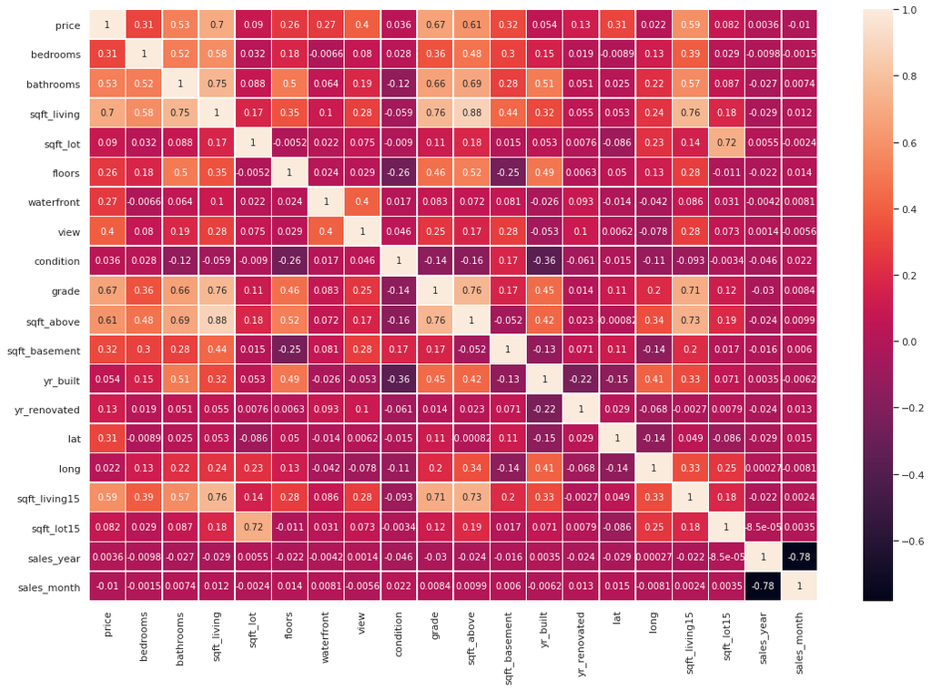

```python
# practice visualizing correlation matrix using a heatmap
# your code here
plt.figure(figsize = (18,12))
sns.heatmap(corrMatrix, annot=True, linewidths=0.5)
```

### 5c) Pair plot [Peer Review]

Pair plot is a fast way to inspect relationships between features. Use seaborn's .pairplot() function to draw a pairplot if the first 10 columns (including price) and inspect their relationships. Set the diagonal elements to be KDE plot. You will upload your pair plot in this week's Peer Review assignment.  
**Note:** your code for this section may cause the Validate button to time out. If you want to run the Validate button prior to submitting, you could comment out the code in this section after completing the Peer Review.

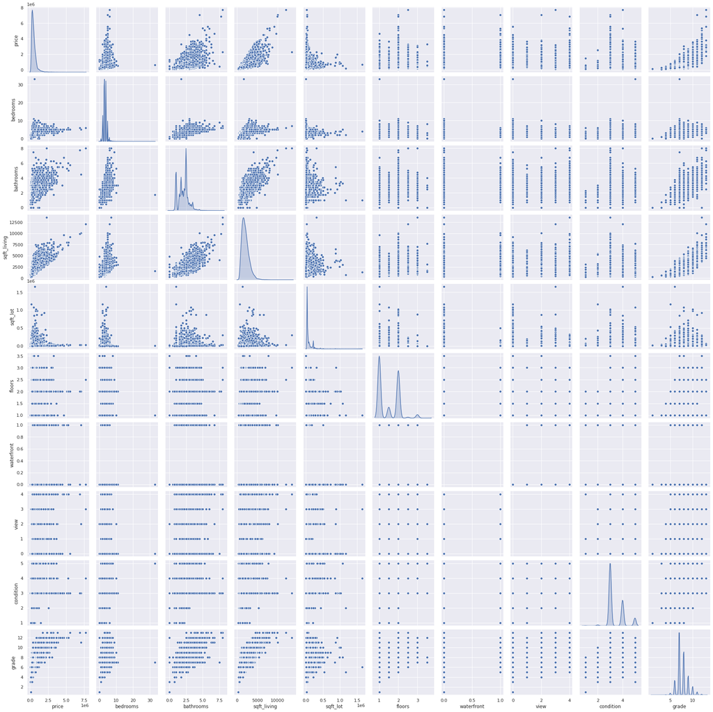

```python
# practice inspecting relationships between features using a pair plot.
# your code here
sns.pairplot(df2, vars = ['price', 'bedrooms', 'bathrooms', 'sqft_living', 'sqft_lot', 'floors', 'waterfront', 'view', 'condition', 'grade'], diag_kind = 'kde')
```

## 6. Simple linear regression [Peer Review]

### 6a) Data preparation [Peer Review]

We will split the data to train and test datasets such that the test dataset is 20% of original data. Use `sklearn.model_selection.train_test_split` function to split the data frame to X_train and X_test. X_train is 80% of observation randomly chosen. X_test is the rest 20%. Both X_train and X_test are `pd.DataFrame` object and include 'price' in the table. Note that the train_test_split can handle data frame as well as array.

```python
# your code here
from sklearn.model_selection import train_test_split
X_train, X_test = train_test_split(df2, test_size = 0.2)
print(len(X_train))
print(len(X_test))
# use sklearn.model_selecttion.train_test_split to split the data frame
# X_train is 80% of the observations; X_test is 20% of the observations
# print length of X_train and X_test
```

```
17290
4323
```

```python
# instructor testing cell
# your code here
```

### 6b) Train a simple linear regression model [Peer Review]

Use the best_guess_predictor as a single predictor and build a simple linear regression model using `statsmodels.formula.api.ols` function (https://www.statsmodels.org/dev/example_formulas.html) Print out the result summary. Train on the X_train portion. What is the adjusted R-squared value?

```python
# use best_guess_predictor as a single predictor
# build a simple linear regression model, train on the X_train portion
# your code here

model = smf.ols(formula = 'price ~ sqft_living', data = X_train)
res = model.fit()
print(res.summary())
adj_R2 = 0.488 #update this value according to the result
```

```
                            OLS Regression Results
==============================================================================
Dep. Variable:                  price   R-squared:                       0.488
Model:                            OLS   Adj. R-squared:                  0.488
Method:                 Least Squares   F-statistic:                 1.648e+04
Date:                Mon, 18 Apr 2022   Prob (F-statistic):               0.00
Time:                        07:47:57   Log-Likelihood:            -2.4023e+05
No. Observations:               17290   AIC:                         4.805e+05
Df Residuals:                   17288   BIC:                         4.805e+05
Df Model:                           1
Covariance Type:            nonrobust
===============================================================================
                  coef    std err          t      P>|t|      [0.025      0.975]
-------------------------------------------------------------------------------
Intercept   -4.413e+04   4951.513     -8.913      0.000   -5.38e+04   -3.44e+04
sqft_living   280.9637      2.189    128.366      0.000     276.673     285.254
==============================================================================
Omnibus:                    11745.133   Durbin-Watson:                   1.987
Prob(Omnibus):                  0.000   Jarque-Bera (JB):           398535.554
Skew:                           2.807   Prob(JB):                         0.00
Kurtosis:                      25.841   Cond. No.                     5.63e+03
==============================================================================

Warnings:
[1] Standard Errors assume that the covariance matrix of the errors is correctly specified.
[2] The condition number is large, 5.63e+03. This might indicate that there are
strong multicollinearity or other numerical problems.
```